# Proyecto: Resumen del dataset starwars del paquete dplyr

Juan Orizabal

13/05/2021

# Descripción de los datos

El data set starwars se enfoca principalmente en los personajes que aparecen en sus peliculas. Los datos originales, de SWAPI, la API de Star Wars, https://swapi.dev/, se han revisado para reflejar investigaciones adicionales sobre las determinaciones de género y sexo de los personajes.

Fuente de datos:

Created by Paul Hallett Maintained by Juriy Bura ©2021

Twitter: https://twitter.com/intent/follow?original_referer=https%3A%2F%2Fswapi.dev%2F&ref_src=twsrc%5Etfw&region=follow_link&screen_name=juriy&tw_p=followbutton

Github: https://github.com/juriy

| Variable | Descripcion |
| --- | --- |
| name | Nombre del personaje |
| height | altura del personaje |
| mass | Peso del personaje |
| hair_color | Color de pelo del personaje |
| skin_color | Color de piel del personaje |
| eye_color | Color de ojo del personaje |
| birth_year | Fecha de cumpleaños del personaje |
| sex | Sexo biologico del personaje |
| gender | La identidad de genero determinado por la personalidad de genero del personaje |
| homeworld | Mundo natal del personaje |
| species | Nombre de la especie del personaje |
| films | Lista de peliculas en las que aparece el personaje |
| vehicles | Lista de vehiculos que ha pilotado el personaje |
| starships | Lista de naves que ha pilotado el personaje |

# Visualizaciones de datos

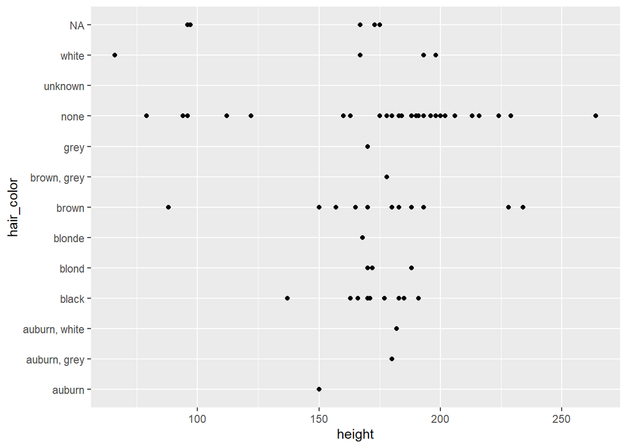

```r
# Escriba el código R aquí para cargar su archivo de datos
library(dplyr)
library(ggplot2)
ggplot(data = starwars) + geom_point(mapping =  aes(x =height, y =hair_color ))
```

El comando lo que hace es hacer un grafico de dispersion entre dos variables, height(variable continua) en el eje x, y Hair color(variable categorica) en el eje Y. Que muestra la relacion entre la altura de los personajes y sus colores de pelo, el que mas elementos tiene es el que no tiene color de pelo. El que menos tiene es unknown que no tiene ningun elemento. Lo que se espera es que el lector entienda o deduzca es como es que existen distintos colores de pelo en funcion de la altura.

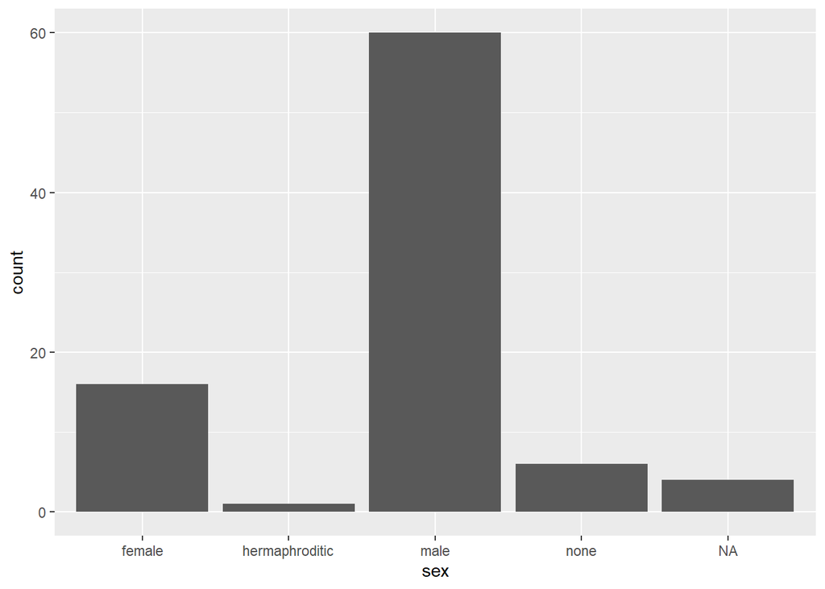

```r
ggplot(data = starwars) + geom_bar(mapping =  aes(x =sex ))
```